# Descriptive Information

## How predictive are cohort and year of birth of participation at each timepoint?

I’ve checked there are no missing values for cohort or year of birth (aonsby)

View full-size plot

```r
models = list()

for (i in seq_along(rq1y_twin1)){
  # cat(i, "/", length(rq1y),"\n")
  formula <- as.formula(paste(rq1y_twin1[i], "~ cohort + aonsby"))
  models[[i]] = glm(formula, data = df, family = binomial)
}

var_explained = sapply(models, function(x) as.numeric(performance::r2(x)))

cbind.data.frame(rq1y_twin1, rq1y_twin_labels_clean, var_explained) %>%
  `colnames<-`(c("Var","Label","R2 by Cohort and Birth Year")) %>%
  knitr::kable(digits = 2)
```

| Var | Label | R2 by Cohort and Birth Year |
| --- | --- | --- |
| dtwdata1 | Y4 (parent-report twin booklet) | 0.01 |
| lcwdata1 | Y12 (web tests) | 0.00 |
| lcqdata1 | Y12 (questionnaire) | 0.00 |
| pcbhdata1 | Y16 (behaviour booklet) | 0.01 |
| rcqdata1 | Y18 (questionnaire) | 0.05 |
| u1cdata1 | Y21 (TEDS21 phase-1 questionnaire) | 0.00 |
| zmhdata1 | Y26 (TEDS26 questionnaire) | 0.00 |
| zcdata1 | Y26 (CATSLife web tests) | 0.00 |
| hasgeno1 | Genotyped | 0.00 |

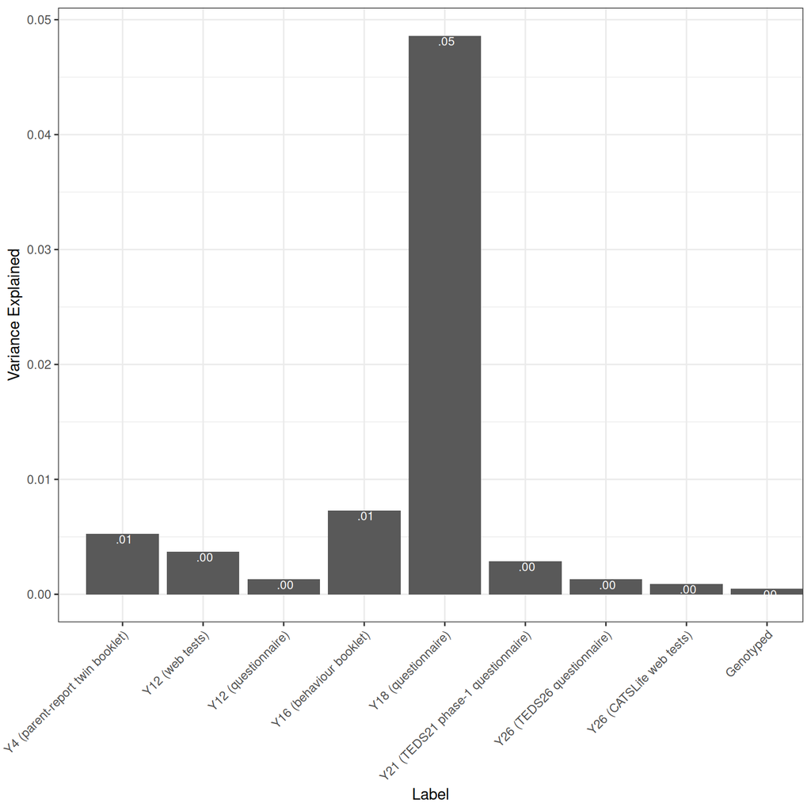

```r
cbind.data.frame(rq1y_twin1, rq1y_twin_labels_clean, var_explained) %>%
  `colnames<-`(c("Var","Label","Variance Explained")) %>%
  mutate(
    Label = factor(Label, levels = rq1y_twin_labels_clean)
  ) %>%
  ggplot(aes(x=Label,y=`Variance Explained`)) +
  geom_col() +
  geom_text(aes(label = gbtoolbox::apa_num(`Variance Explained`)),
            vjust = 1.1, color = "white", size = 3) +
  theme_bw() +
  theme(axis.text.x = element_text(angle = 45, hjust=1, vjust=1)) +
  scale_x_discrete(expand = expansion(mult = c(0.1, 0)))
```

```r
save_plot("11_r2_participation_cohort_birthyear", width = 9, height = 5)
```

View full-size plot

At the Y18 time point, we see that those in cohort 1 and those born in 1994 are less likely to participate.

```r
rq1y_twin_labels_clean[5]
```

```
[1] "Y18 (questionnaire)"
```

```r
summary(models[[5]])
```

```
Call:
glm(formula = formula, family = binomial, data = df)

Coefficients:
                                            Estimate Std. Error z value
(Intercept)                                 -0.68069    0.02705 -25.167
cohortCohort 2: twins born Sep-94 to Aug-95  0.95440    0.04529  21.073
cohortCohort 3: twins born Sep-95 to Aug-96  0.89800    0.06416  13.997
cohortCohort 4: twins born Sep-96 to Dec-96  0.73824    0.08009   9.217
aonsby1995                                   0.19060    0.04498   4.237
aonsby1996                                   0.16098    0.06522   2.468
                                            Pr(>|z|)
(Intercept)                                  < 2e-16 ***
cohortCohort 2: twins born Sep-94 to Aug-95  < 2e-16 ***
cohortCohort 3: twins born Sep-95 to Aug-96  < 2e-16 ***
cohortCohort 4: twins born Sep-96 to Dec-96  < 2e-16 ***
aonsby1995                                  2.26e-05 ***
aonsby1996                                    0.0136 *
---
Signif. codes:  0 '***' 0.001 '**' 0.01 '*' 0.05 '.' 0.1 ' ' 1

(Dispersion parameter for binomial family taken to be 1)

    Null deviance: 35773  on 25875  degrees of freedom
Residual deviance: 34503  on 25870  degrees of freedom
AIC: 34515

Number of Fisher Scoring iterations: 4
```

### Cohort alone is not helpful for determining who was eligible at t2 and t3

As we can see below, nobody in cohort 4 took part in Y2, Y3, Y10 data collection. However, a minority of participants took part in Y2-Y3 from cohort 3, but participation rates are quite low suggesting that some participants were eligible and some were not.

```r
 table(df0$cohort, df0$btwoyear)
```

```
       0    1
  1 1866 4664
  2 3900 5876
  3 6558 1978
  4 3048    0
```

```r
 table(df0$cohort, df0$cthreeyr)
```

```
       0    1
  1 2348 4182
  2 3838 5938
  3 6622 1914
  4 3048    0
```

```r
 table(df0$cohort, df0$jtenyear)
```

```
       0    1
  1 3794 2736
  2 4390 5386
  3 8536    0
  4 3048    0
```

```r
 table(df0$AONSBY, df0$btwoyear)
```

```
          0    1
  1994 2788 7036
  1995 4320 5482
  1996 8264    0
```

```r
 table(df0$AONSBY, df0$cthreeyr)
```

```
          0    1
  1994 3678 6146
  1995 3914 5888
  1996 8264    0
```

```r
 table(df0$AONSBY, df0$jtenyear)
```

```
          0    1
  1994 5288 4536
  1995 6216 3586
  1996 8264    0
```

## Participation Patterns

```
ℹ 70 missing data patterns were requested.
ℹ 73 missing data patterns are shown.
ℹ 369 missing data patterns are hidden.
replace the existing one.
```

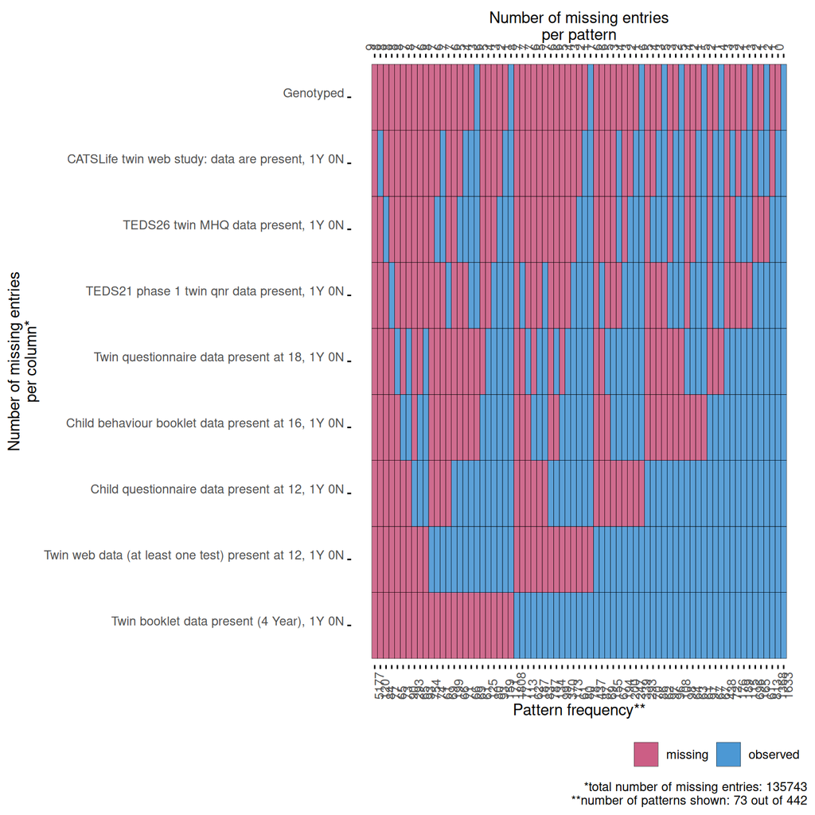

```r
df %>%
  select(all_of(rq1y_twin1)) %>%
  rename_with(~var_to_label(., df)) %>%
  mutate_all(~na_if(., 0)) %>%
  ggmice::plot_pattern(npat = 70, rotate = TRUE) +
  scale_x_discrete(limits = (var_to_label(rq1y_twin1))) +
  coord_flip()
```

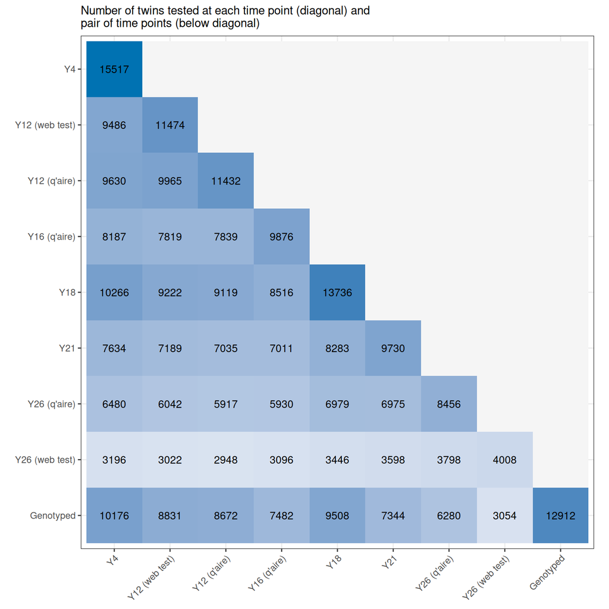

```r
save_plot("11_participation_pattern", width = 19, height = 6)


# df %>%
#   select(all_of(rq1y_twin1)) %>%
#   mutate_all(~ .==1) %>%
#   rowwise() %>%
#   mutate(
#     `Year 2 - 4 present`   = any(btwoyear, cthreeyr, dfouryr),
#     `Year 7 - 12 present`  = any(gsevenyr, heightyr, jtenyear),
#     `Year 14 - 16 present` = any(n14year, p16year),
#     `Year 18 - 26 present` = any(rcqdata, uteds21data, zmhdata)
#   ) %>%
#   select(ends_with("present")) %>%
#   mutate_all(~ na_if(., FALSE)) %>%
#   ggmice::plot_pattern(rotate = TRUE) +
#   scale_x_discrete(limits = c("Year 2 - 4 present", "Year 7 - 12 present", "Year 14 - 16 present", "Year 18 - 26 present")) +
#   coord_flip()
#
# save_plot("11_participation_pattern_grouped", width = 19, height = 6)

df %>%
  select(all_of(rq1y_twin1)) %>%
  `colnames<-`((rq1y_twin_labels_clean_extrashort)) %>%
  mutate_all(~ na_if(., 0)) %>%
  gbtoolbox::plot_pairwise_missing(textadjust = 2.5) +
  labs(subtitle = "Number of twins tested at each time point (diagonal) and \npair of time points (below diagonal)")
```

```r
save_plot("11_pairwise_missingness_plot", width = 6, height = 6)
```

View full-size plot

View full-size plot

# Descriptive stats on specific variables

## Availability of genotyped data by sex/zygosity and ethnicity

Note that below, the double entered twin variable `genotyped1/2` indicates the presence (1) or absence (0) of genotyped data (see [data dictionary](https://datadictionary.teds.ac.uk/studies/variable_lists/background_variables.htm)).

For the analyses, I created the variables `geno1/2` which sets the value to 1 if one has an MZ twin that has been genotyped.

Sex/Zygosity

```r
df %>%
    split(.$sexzyg) %>%
    map(~ table(.x$genotyped1, .x$genotyped2))
```

```
$`MZ male`

       0    1
  0 1714 1242
  1 1242    0

$`DZ male`

       0    1
  0 2134  267
  1  267 1646

$`MZ female`

       0    1
  0 1696 1416
  1 1416    0

$`DZ female`

       0    1
  0 1864  236
  1  236 1820

$`DZ opposite sexes`

       0    1
  0 4542  495
  1  495 3148
```

```r
df %>%
    split(.$sexzyg) %>%
    map(~ table(.x$hasgeno1, .x$hasgeno2))
```

```
$`MZ male`

       0    1
  0 1408    0
  1    0 2476

$`DZ male`

       0    1
  0 1808  266
  1  266 1646

$`MZ female`

       0    1
  0 1248    0
  1    0 2826

$`DZ female`

       0    1
  0 1568  235
  1  235 1820

$`DZ opposite sexes`

       0    1
  0 3840  495
  1  495 3148
```

Ethnicity

```r
df %>%
    group_by(aethnicc) %>%
    summarise(
      `N genotyped` = length(which(genotyped1 == 1)),
      `% genotyped` = length(which(genotyped1 == 1))/dplyr::n()
    ) %>%
  gt() %>%
  fmt_percent(columns = 3)
```

| Ethnic origin of twins, original codes (1st Contact), see value labels | N genotyped | % genotyped |
| --- | --- | --- |
| White | 10261 | 43.15% |
| Asian | 0 | 0.00% |
| Black | 0 | 0.00% |
| Mixed race | 2 | 0.25% |
| Other | 4 | 2.53% |
| NA | 3 | 3.19% |

## Age of twins at each time point

View full-size plot

### Plot

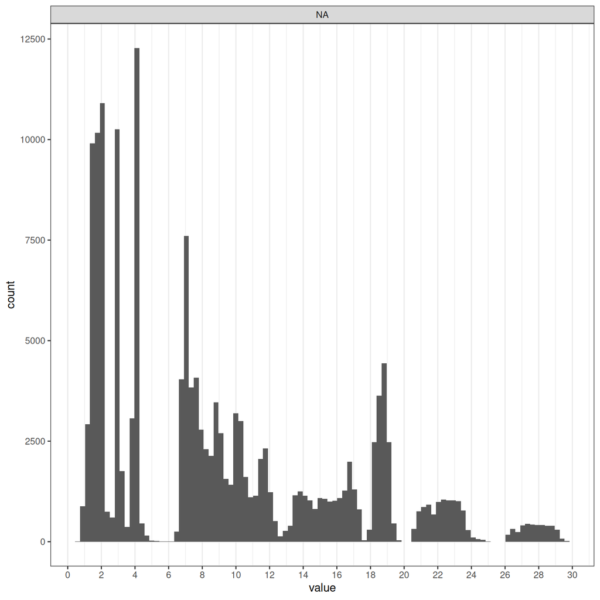

```r
df_age = df %>%
  select(contains("age")) %>%
  select(-contains("genpro"), -contains("mumage"), - contains("dadage"), -ends_with("2"))

df_age_long = df_age %>%
  `colnames<-`(paste0(var_to_label(colnames(df_age)), " (", colnames(df_age), ")")) %>%
  pivot_longer(cols = everything())

df_age_long %>%
  mutate(name = factor(name, levels = var_to_label(colnames(df_age)))) %>%
  ggplot(aes(x=value)) +
  geom_histogram(bins = 100) +
  facet_wrap(~name, ncol =3) +
  scale_x_continuous(breaks = seq(0,30,by=2)) +
  theme_bw() +
  theme(
    panel.grid.major.y = element_blank(),
    panel.grid.minor.y = element_blank()
    )
```

```r
save_plot("11_participant_ages_each_timepoint", width = 12, height = 12)
```

View full-size plot

### Participant Ages at Each Timepoint

```r
df_age_long %>%
  mutate(name = factor(name, levels = paste0(var_to_label(colnames(df_age)), " (", colnames(df_age), ")"))) %>%
  group_by(name) %>%
  summarise(
    n = sum(!is.na(value)),
    mean = mean(value, na.rm = TRUE),
    sd = sd(value, na.rm = TRUE),
    min = min(value, na.rm = TRUE),
    p10 = quantile(value, 0.10, na.rm = TRUE),
    p90 = quantile(value, 0.90, na.rm = TRUE),
    max = max(value, na.rm = TRUE),
    .groups = "drop"
  ) %>%
  gt() %>%
  cols_label(
    name = "Timepoint",
    n = "N",
    mean = "Mean",
    sd = "SD",
    min = "Min",
    p10 = "10th",
    p90 = "90th",
    max = "Max"
  ) %>%
  fmt_number(
    columns = c(mean, sd),
    decimals = 2
  ) %>%
  fmt_number(
    columns = c(min, p10, p90, max),
    decimals = 1
  ) %>%
  fmt_number(
    columns = n,
    use_seps = TRUE,
    decimals = 0
  ) %>%
  tab_header(
    title = "Participant Age at Each Timepoint"
  ) %>%
  tab_style(
    style = cell_text(weight = "bold"),
    locations = cells_column_labels()
  )
```

Participant Age at Each Timepoint

| Timepoint | N | Mean | SD | Min | 10th | 90th | Max |
| --- | --- | --- | --- | --- | --- | --- | --- |
| Age in years of twins at time of 1st Contact (atwinage) | 25,862 | 1.82 | 1.20 | 0.7 | 1.3 | 2.0 | 18.7 |
| Twin age in years on completion of parent booklet (2 Year) (bpbage) | 11,876 | 2.05 | 0.17 | 1.0 | 1.9 | 2.2 | 4.5 |
| Twin age in years on completion of parent booklet (3 Year) (cpbage) | 11,600 | 3.00 | 0.10 | 1.9 | 2.9 | 3.1 | 4.0 |
| Twin age in years on completion of parent booklet (4 Year) (dpbage) | 15,580 | 4.02 | 0.13 | 2.9 | 3.9 | 4.1 | 6.8 |
| Age of twins when parent booklet completed at 7 (gpbage) | 14,862 | 7.12 | 0.27 | 6.3 | 6.8 | 7.5 | 10.0 |
| Age of twins when 8 year questionnaire completed (years) (hage) | 12,922 | 7.93 | 0.53 | 6.9 | 7.2 | 8.7 | 9.5 |
| Age of twins (years) when parent and child booklets completed at 9 (icpage) | 6,675 | 9.02 | 0.28 | 8.5 | 8.7 | 9.4 | 10.1 |
| Age of twin (years) when web tests started at 10 (jcstage1) | 6,199 | 10.07 | 0.29 | 9.4 | 9.7 | 10.4 | 10.8 |
| Age of twin when 12yr child questionnaire returned, years (lcqage1) | 11,529 | 11.28 | 0.70 | 9.8 | 10.2 | 12.1 | 15.6 |
| Age of twin when child questionnaire returned at 14, years (ncqage1) | 6,637 | 14.07 | 0.58 | 12.8 | 13.4 | 14.9 | 20.3 |
| Age of twin on return of behaviour study child booklet at 16, years (pcbhage1) | 9,948 | 16.32 | 0.69 | 14.9 | 15.3 | 17.1 | 21.3 |
| Age of twin on return of 18 year questionnaire, years (rcqage1) | 13,765 | 18.67 | 0.33 | 18.0 | 18.2 | 19.1 | 19.9 |
| Age of twin when TEDS21 phase 1 twin qnr completed, years (u1cage1) | 9,927 | 22.27 | 0.92 | 20.5 | 21.0 | 23.4 | 27.1 |
| Age of twin when CATSLife study activities started, years (zcage1) | 4,008 | 27.76 | 0.87 | 26.1 | 26.6 | 28.9 | 29.8 |

## Maternal Education Distribution

```r
all(table(df$amohqual)==table(df$amohqualn))
```

```
[1] TRUE
```

```r
df %>%
  filter(twin == 1) %>%
  count(amohqual) %>%
  mutate(
    numeric_code = as.numeric(amohqual),
    percent = n / sum(n)
  ) %>%
  select(numeric_code, amohqual, n, percent) %>%
  gt() %>%
  cols_label(
    numeric_code = "Code",
    amohqual = "Education Level",
    n = "N",
    percent = "Percent"
  ) %>%
  fmt_percent(columns = percent)
```

| Code | Education Level | N | Percent |
| --- | --- | --- | --- |
| 1 | no qualifications | 1198 | 9.26% |
| 2 | CSE grade 2-5 or O-level/GCSE grade D-G | 1989 | 15.37% |
| 3 | CSE grade 1 or O-level/GCSE grade A-C | 4754 | 36.74% |
| 4 | A-level or S-level | 1693 | 13.09% |
| 5 | HNC | 356 | 2.75% |
| 6 | HND | 484 | 3.74% |
| 7 | undergraduate degree | 1484 | 11.47% |
| 8 | postgraduate qualification | 775 | 5.99% |
| NA | NA | 205 | 1.58% |

## Relationship between maternal education and child outcomes

In some analyses, maternal education is treated as a numeric variable (1-8), which assumes a linear relationship with child outcomes. To check whether this assumption is reasonable, we examine the predicted child education & cognition outcomes at each maternal education level.

We regress child outcomes on maternal education using dummy coding (i.e., treating each education level as a separate category). The plots below show the predicted outcome for each education level. If the linearity assumption holds, these points should fall approximately on a straight line.

We find that mothers with A Levels have generally similar child outcomes to those with Higher National Certificate and Higher National Diploma qualifications. Thus, the assumption of linearity seems unreasonable, and it might be problematic to have these two categories as separate numeric codes.

```r
# Helper function to create marginal effects plot
plot_education_effects = function(model, y_label) {
  marginaleffects::predictions(model, by = "amohqual") %>%
    data.frame() %>%
    rename(
      prediction = estimate,
      education_level = amohqual
    ) %>%
    ggplot(aes(y = prediction, x = education_level, group = 1)) +
    geom_errorbar(aes(ymin = conf.low, ymax = conf.high), width = 0.2) +
    geom_point(size = 2) +
    geom_line() +
    labs(
      x = "Maternal Education Level",
      y = y_label
    ) +
    theme_bw() +
    theme(
      axis.text.x = element_text(angle = 45, hjust = 1, vjust = 1)
    )
}
```

### KS3 Academic Achievement (Age 14)

```r
model_ks3 = df %>%
  filter(twin == 1) %>%
  filter(!is.na(amohqual)) %>%
  lm(npks3tall1 ~ amohqual, data = .)

summary(model_ks3)
```

```
Call:
lm(formula = npks3tall1 ~ amohqual, data = .)

Residuals:
    Min      1Q  Median      3Q     Max
-4.8343 -0.4258  0.0387  0.4676  3.4833

Coefficients:
                                                Estimate Std. Error t value
(Intercept)                                      5.23404    0.06750  77.546
amohqualCSE grade 2-5 or O-level/GCSE grade D-G  0.28271    0.08063   3.506
amohqualCSE grade 1 or O-level/GCSE grade A-C    0.54034    0.07144   7.563
amohqualA-level or S-level                       0.78212    0.07622  10.261
amohqualHNC                                      0.66686    0.10411   6.405
amohqualHND                                      0.66195    0.09343   7.085
amohqualundergraduate degree                     0.97547    0.07645  12.759
amohqualpostgraduate qualification               1.01003    0.08398  12.028
                                                Pr(>|t|)
(Intercept)                                      < 2e-16 ***
amohqualCSE grade 2-5 or O-level/GCSE grade D-G 0.000462 ***
amohqualCSE grade 1 or O-level/GCSE grade A-C   5.36e-14 ***
amohqualA-level or S-level                       < 2e-16 ***
amohqualHNC                                     1.77e-10 ***
amohqualHND                                     1.77e-12 ***
amohqualundergraduate degree                     < 2e-16 ***
amohqualpostgraduate qualification               < 2e-16 ***
---
Signif. codes:  0 '***' 0.001 '**' 0.01 '*' 0.05 '.' 0.1 ' ' 1

Residual standard error: 0.7394 on 2687 degrees of freedom
  (10038 observations deleted due to missingness)
Multiple R-squared:   0.11, Adjusted R-squared:  0.1076
F-statistic: 47.43 on 7 and 2687 DF,  p-value: < 2.2e-16
```

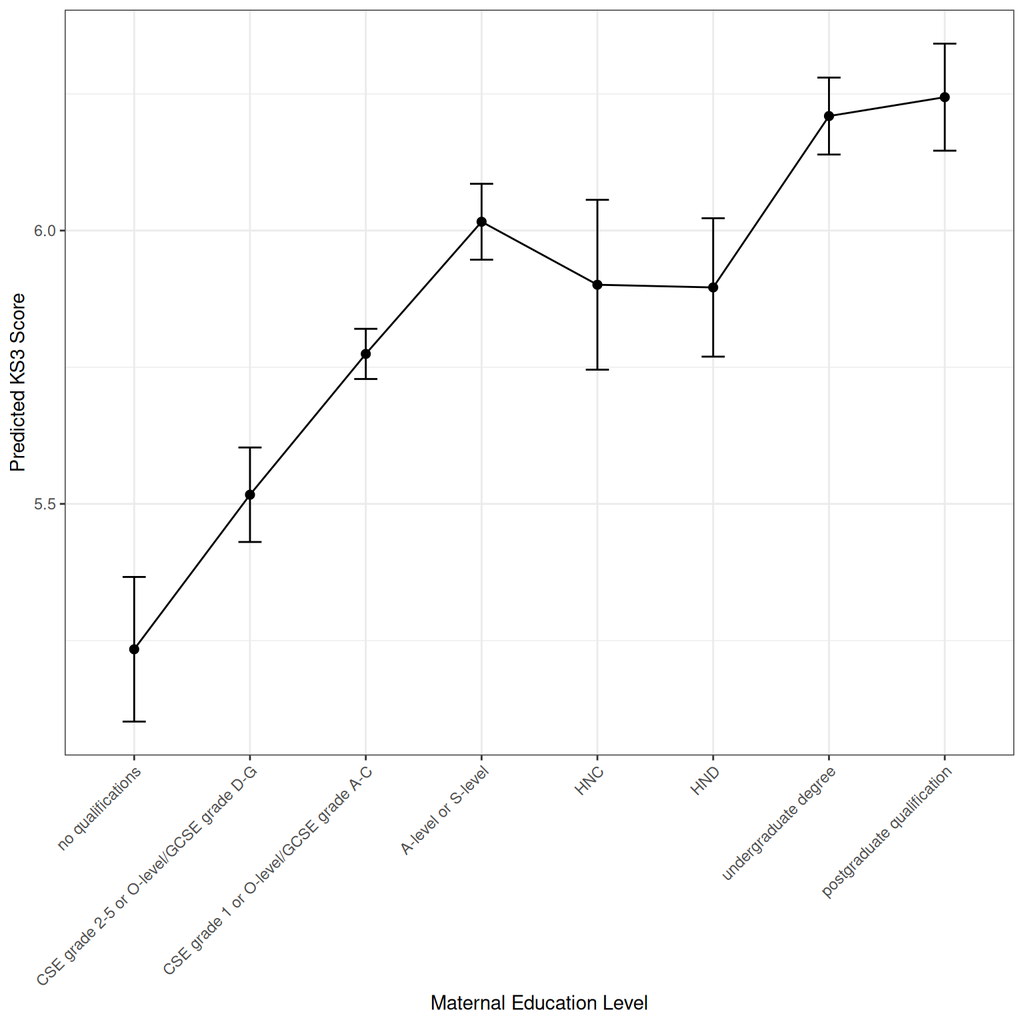

```r
plot_education_effects(model_ks3, "Predicted KS3 Score")
```

```r
save_plot("11_meducation_ks3_plot", width = 6, height = 5)
```

View full-size plot

### GCSE Core Subjects Grade (Age 16)

```r
model_gcse = df %>%
  filter(twin == 1) %>%
  filter(!is.na(amohqual)) %>%
  lm(pcexgcsecoregrdm1 ~ amohqual, data = .)

summary(model_gcse)
```

```
Call:
lm(formula = pcexgcsecoregrdm1 ~ amohqual, data = .)

Residuals:
    Min      1Q  Median      3Q     Max
-4.8199 -0.6750  0.0801  0.8085  3.0983

Coefficients:
                                                Estimate Std. Error t value
(Intercept)                                      7.90170    0.06447 122.557
amohqualCSE grade 2-5 or O-level/GCSE grade D-G  0.28982    0.07583   3.822
amohqualCSE grade 1 or O-level/GCSE grade A-C    0.77326    0.06831  11.319
amohqualA-level or S-level                       1.21822    0.07365  16.540
amohqualHNC                                      1.14144    0.10074  11.331
amohqualHND                                      1.21801    0.09240  13.182
amohqualundergraduate degree                     1.74640    0.07336  23.806
amohqualpostgraduate qualification               1.79888    0.08084  22.253
                                                Pr(>|t|)
(Intercept)                                      < 2e-16 ***
amohqualCSE grade 2-5 or O-level/GCSE grade D-G 0.000134 ***
amohqualCSE grade 1 or O-level/GCSE grade A-C    < 2e-16 ***
amohqualA-level or S-level                       < 2e-16 ***
amohqualHNC                                      < 2e-16 ***
amohqualHND                                      < 2e-16 ***
amohqualundergraduate degree                     < 2e-16 ***
amohqualpostgraduate qualification               < 2e-16 ***
---
Signif. codes:  0 '***' 0.001 '**' 0.01 '*' 0.05 '.' 0.1 ' ' 1

Residual standard error: 1.105 on 6408 degrees of freedom
  (6317 observations deleted due to missingness)
Multiple R-squared:  0.1827,    Adjusted R-squared:  0.1818
F-statistic: 204.6 on 7 and 6408 DF,  p-value: < 2.2e-16
```

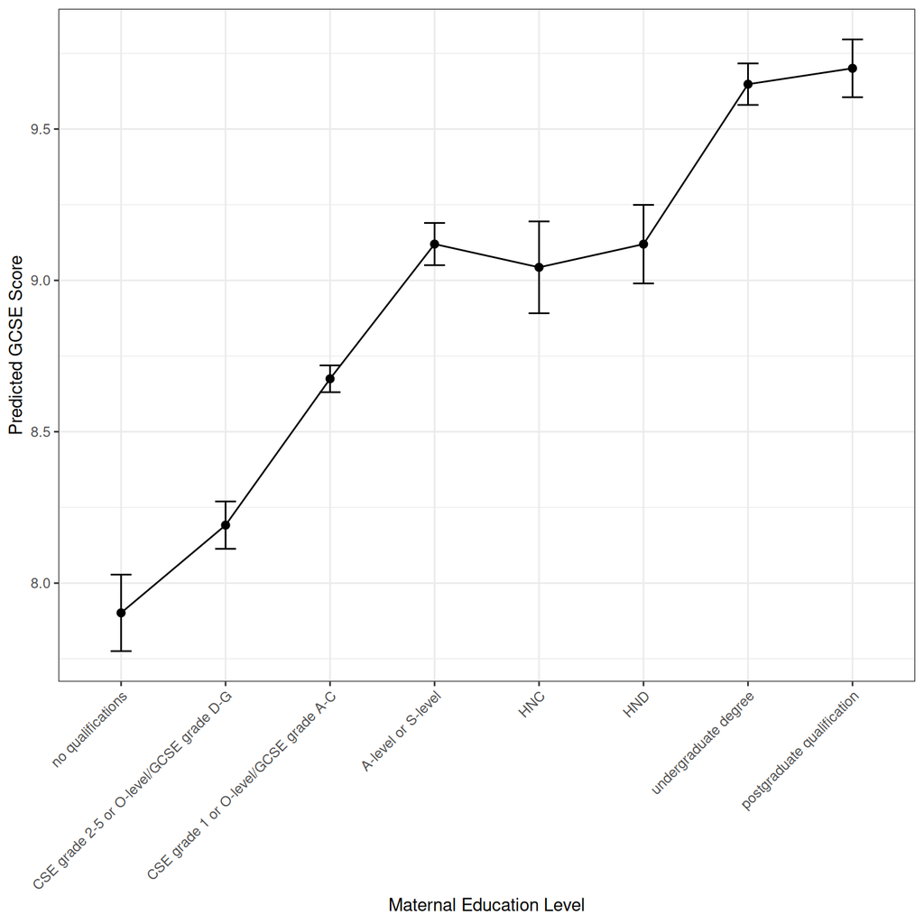

```r
plot_education_effects(model_gcse, "Predicted GCSE Score")
```

```r
save_plot("11_meducation_gcse_plot", width = 6, height = 5)
```

View full-size plot

### Cognitive Ability (Age 12)

```r
model_cog = df %>%
  filter(twin == 1) %>%
  filter(!is.na(amohqual)) %>%
  lm(lcg1 ~ amohqual, data = .)

summary(model_cog)
```

```
Call:
lm(formula = lcg1 ~ amohqual, data = .)

Residuals:
    Min      1Q  Median      3Q     Max
-3.8007 -0.6221  0.0559  0.6793  2.6533

Coefficients:
                                                Estimate Std. Error t value
(Intercept)                                     -0.54041    0.06527  -8.280
amohqualCSE grade 2-5 or O-level/GCSE grade D-G  0.23787    0.07856   3.028
amohqualCSE grade 1 or O-level/GCSE grade A-C    0.43512    0.06983   6.232
amohqualA-level or S-level                       0.66805    0.07569   8.826
amohqualHNC                                      0.58609    0.10731   5.462
amohqualHND                                      0.64825    0.09592   6.758
amohqualundergraduate degree                     0.92577    0.07495  12.351
amohqualpostgraduate qualification               0.93773    0.08319  11.272
                                                Pr(>|t|)
(Intercept)                                      < 2e-16 ***
amohqualCSE grade 2-5 or O-level/GCSE grade D-G  0.00248 **
amohqualCSE grade 1 or O-level/GCSE grade A-C   5.07e-10 ***
amohqualA-level or S-level                       < 2e-16 ***
amohqualHNC                                     4.99e-08 ***
amohqualHND                                     1.59e-11 ***
amohqualundergraduate degree                     < 2e-16 ***
amohqualpostgraduate qualification               < 2e-16 ***
---
Signif. codes:  0 '***' 0.001 '**' 0.01 '*' 0.05 '.' 0.1 ' ' 1

Residual standard error: 0.9637 on 4186 degrees of freedom
  (8539 observations deleted due to missingness)
Multiple R-squared:  0.06999,   Adjusted R-squared:  0.06843
F-statistic:    45 on 7 and 4186 DF,  p-value: < 2.2e-16
```

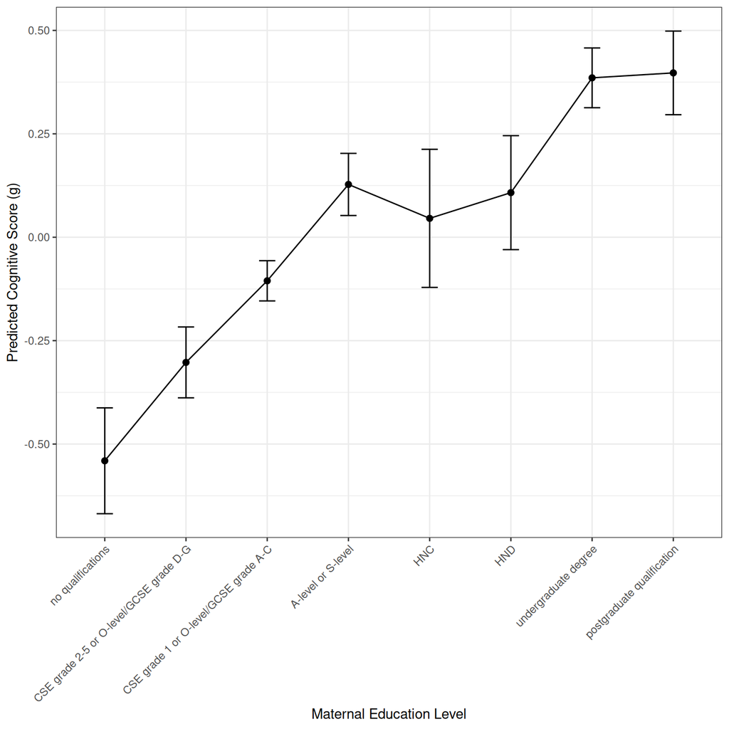

```r
plot_education_effects(model_cog, "Predicted Cognitive Score (g)")
```

```r
save_plot("11_meducation_cognitive_plot", width = 6, height = 5)
```

View full-size plot